# Big Data Tools: Hadoop, Mapreduce, Pig, Hive, Impala

Aug 23, 2018

## What is big data?

- 3V is most commonly used characterization for big data challenge
- **Volume** of the data may exceed the physical capacity
  - Google receives over 2 million search queries every minute
  - transactional data or sensor data are being stored every fraction of seconds
- **Variety** of data does not have any bound
  - YouTube, Facebook generate video, audio, image and text data
  - Over 200 million emails are sent every minute
- **Velocity**
  - Experiments at [CERN](http://home.web.cern.ch/about/computing) generate colossal amounts of data.
    - Particles collide 600 million times per second.
    - Data Center processes about one petabyte of data per day.

## Challenges with big data

- Storage and cost are big issues
  - 99.999 percent of all the data are thrown away by CERN hadron collider
    - even with the rest of the data they don't have the capacity to store
    - they built a worldwide grid system to store and process the data
- The **Value** of data depends on how they are being used
  - we only have finite time to process
  - processing power is not unbounded
- How can this problem be solved?

## Parallel computing

- The limitation of processing power can be overcome at some scale
  - if a process takes a year to run, use 365 processors to run it in a day
    - the challenge is to be able to parallelize the task
    - another challenge is the failure of one or more processors
    - we need some sort of automation in this process
- How this challenge of parallel processing of data can be performed?
  - google file system [paper](http://static.googleusercontent.com/external_content/untrusted_dlcp/research.google.com/en/us/archive/gfs-sosp2003.pdf)
  - google mapreduce [paper](http://static.googleusercontent.com/media/research.google.com/en/us/archive/mapreduce-osdi04.pdf)

## What is Hadoop?

```bash
    __  __          __
   / / / /___ _____/ /___  ____  ____
  / /_/ / __ `/ __  / __ \/ __ \/ __ \
 / __  / /_/ / /_/ / /_/ / /_/ / /_/ /
/_/ /_/\__,_/\__,_/\____/\____/ .___/
                             /_/
```

- It is a software platform
  - allows us easily write and run data related applications
  - facilitates processing and manipulating massive amount of data
  - the processes are conveniently scalable
- The core hadoop system runs with
  - Hadoop Distributed File System (**HDFS**)
  - **MapReduce**: a system for parallel processing of massive amount of data

## Scalability of processes

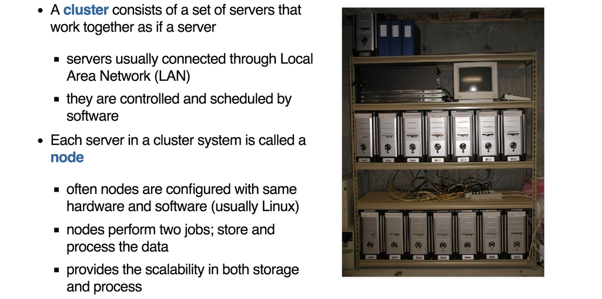

The symbolic picture is taken from [wikipedia](http://upload.wikimedia.org/wikipedia/commons/8/8c/Beowulf.jpg)

## Why Hadoop

- Hadoop allows scalable process
  - to increase cluster capacity, add more nodes
- Fault-tolerant system:
  - includes redundant nodes, automatically restarts failed jobs
  - each node processes a small amount of data
  - files are replicated on different nodes
- Cost is very low without compromising the performance
- Made it possible to handle a massive amount of data conveniently

## Who uses Hadoop

- **Facebook** uses Apache Hadoop to store copies of internal log and dimension data sources and use it as a source for reporting/analytics and machine learning
- **Ebay** is using it for Search optimization and Research
- **Twitter** uses Apache Hadoop to store and process tweets, log files, and many other types of data generated across Twitter
- **HCC** (Holland Computing Center), University of Nebraska runs one medium-sized Hadoop cluster (1.6PB) to store and serve up physics data
- **Yahoo** uses Hadoop to support research for Ad Systems and Web Search
- To find out a detailed list you may like to visit the Hadoop users [wiki](http://wiki.apache.org/hadoop/PoweredBy)

## HDFS

- Based on the google paper about google file system
  - A scalable distributed file system for large distributed data-intensive applications
  - provides fault tolerance while running on inexpensive commodity hardware
  - delivers high aggregate performance
- The file system works like Unix file system
  - paths can be found similar way (such as /myHdfs/testFile.txt)
  - ownership and permission of the files are similar
- But HDFS is not exactly Unix file system
  - files can't be modified once written
  - to work on files, hadoop specific commands need to be used

## How HDFS works

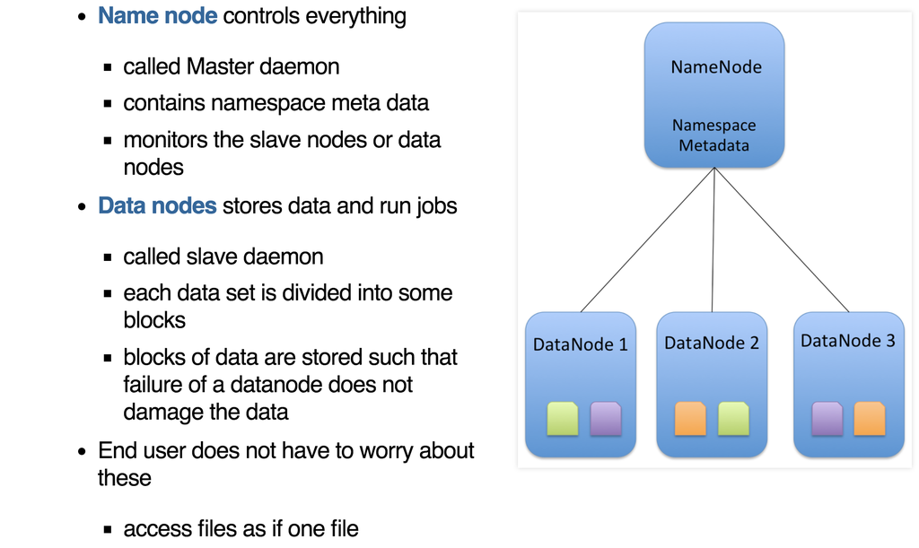

## HDFS and Linux

- HDFS works like Linux file system
  - Linux directory structure such as (myHdfs/myFile.txt)
  - you can view the list of hdfs files as if they are Linux files
- You have to use hadoop specific commands to talk
  - usually any hadoop command should start with `hadoop fs`
  - for example to list all the files in a hdfs folder myHdfs would be
    - `hadoop fs -ls myHdfs`

```bash
Found 1 items
-rw-r--r-- training training 669879113 2014-10-11 23:50 myHdfs/test.csv
```

## MapReduce

- Based on 2nd google paper.
  - each job is splitted into many small jobs
  - There are two procedures
  - `map` filters and sort the data
  - `reduce` summarize the data
  - reduce is not necessary, you can have map only process
  - this facilitates scalability and parallelization
- Each job in MapReduce process are processed in datanode
  - jobs are simple and nodes perform similar jobs
  - when combined together, operation could be powerful and even complex
  - it is necessary to write MapReduce program with great care

## MapReduce example

A MapReduce program's workflow to count the number of words

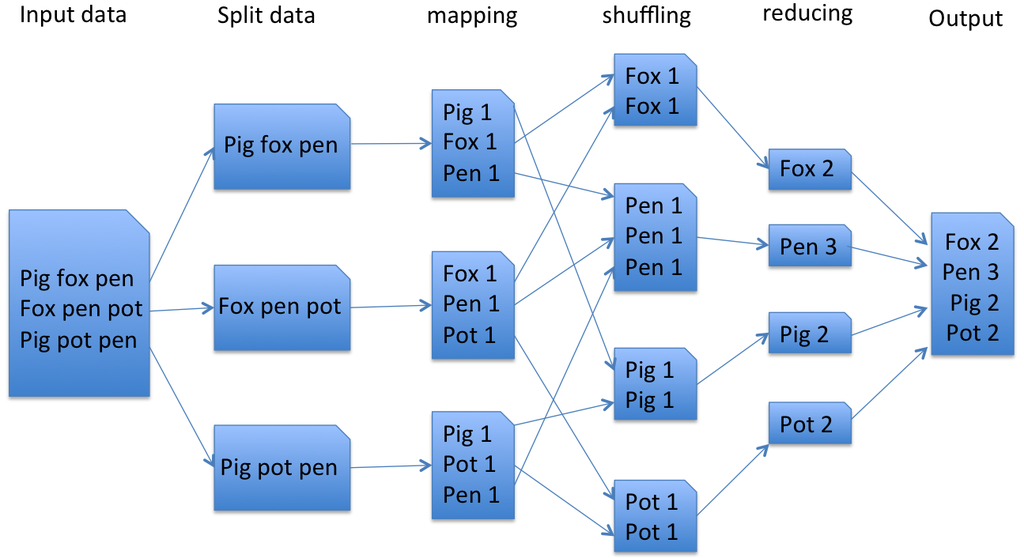

## Pig

- **Pig** is a high level programming language to work under HDFS
  - it is an alternative to low level MapReduce programs
  - works like dplyr language

```r
titanic = LOAD '/user/training/titanic' AS (pclass, survived);
 groups = GROUP titanic BY pclass;
 result = FOREACH groups GENERATE group, SUM(titanic.survived) AS t;
DUMP result;
```

- Pig interpreter works as a wrapper
  - translates the user commands into MapReduce jobs
  - sends the instructions to the cluster

## Hive

- Hive is another high level programming language to work with HDFS
  - it also bases on MapReduce
- Like pig, Hive interpreter works as a wrapper as well
  - translates the user commands into MapReduce jobs
  - sends the instructions to the cluster
- Hive language is similar to SQL, it is called `HiveQL`

```r
  SELECT pclass, sum(survived) as total_survived
    FROM titanic
GROUP BY pclass
ORDER BY pclass;
```

## HBase

- **HBase** is the `Hadoop database`
  - can handle a table of size even petabyte
  - tables can have thousands of columns
- For HBase there is no SQL like language. So, the language is noSQL
  - uses some sort of API type connections to interact with data

## Impala

- Impala is another high level programming language to work with HDFS and HBase
  - it does not rely on MapReduce tasks, has its own technology
  - it is maintained by Cloudera
  - Cloudera claims that it is 10 times faster than Hive or any MapReduce2 jobs

## R and Hadoop

- You can use R to work under HDFS or HBase
- more information about `RHadoop` can be found in their [github repository](https://github.com/RevolutionAnalytics/RHadoop/wiki)
- you need to install several packages
  - `ravro` - read and write files in avro format
  - `plyrmr` - higher level plyr-like data processing for structured data
  - `rmr` - for MapReduce functionality in R
  - `rhdfs` - for HDFS file management from within R
  - `rhbase` - for database management with HBase
- More examples of R and mapreduce can be found in Chapters 17, Modern Data Science with R by Baumer et. al.

## Sqoop

- Sqoop works to transport data from RDBMS to HDFS
  - sqoop import example

```r
 sqoop import \
    --connect jdbc:mysql://localhost \
    --username training --password training123 \
    --warehouse-dir /myHdfs \
    --table titanic
```

- You can use sqoop to send data from HDFS to data base as well

## Reading and References

- Chapters 17, Modern Data Science with R by Baumer et. al.
- google file system [paper](http://static.googleusercontent.com/external_content/untrusted_dlcp/research.google.com/en/us/archive/gfs-sosp2003.pdf)
- google mapreduce [paper](http://static.googleusercontent.com/media/research.google.com/en/us/archive/mapreduce-osdi04.pdf)